# NDFS Synthesis Manuscript: Chlorophyll analysis

Models using weekly average flow as continuous predictor

Dave Bosworth

March 03, 2026

# Purpose

Explore and analyze the continuous chlorophyll data to be included in the NDFS synthesis manuscript. We will attempt to fit multiple models to predict weekly average chlorophyll fluorescence values. All models will only include representative stations for 4 habitat types - upstream (RD22), lower Yolo Bypass (STTD), Cache Slough complex (LIB), and downstream (RVB). At a minimum, the models will contain the two categorical variables - Year and Station - as predictor variables. In some of the models, we will add weekly average flow as a continuous predictor which replaces the categorical predictor - flow action period - in the original analysis. Additionally, we’ll add a GAM smooth for Week number term to account for seasonality in some of the models. After fitting multiple models, we’ll use a model selection process to determine the best one.

# Global code and functions

```r
# Load packages
library(tidyverse)
library(scales)
library(knitr)
library(mgcv)
library(car)
library(gratia)
library(ggeffects)
library(emmeans)
library(multcomp)
library(here)
library(conflicted)

# Source functions
source(here("manuscript_synthesis/src/global_functions.R"))

# Declare package conflict preferences
conflicts_prefer(dplyr::filter(), dplyr::lag(), dplyr::select())
```

# Import Data

```r
# Define file path for processed data
fp_data <- here("manuscript_synthesis/data/processed")

# Import weekly average water quality data
df_wq <- readRDS(file.path(fp_data, "wq_week_avg_2013-2019.rds"))

# Import weekly average flow data
df_flow <- readRDS(file.path(fp_data, "flow_week_avg_2013-2019.rds"))
```

# Prepare Data

```r
# Create a vector for the factor order of StationCode
sta_order <- c("RD22", "STTD", "LIB", "RVB")

# We will use LIS flow data for all stations except for RD22
df_flow_c <- bind_rows(
  expand_grid(
    StationCode = c("STTD", "LIB", "RVB"),
    df_flow |> filter(StationCode == "LIS") |> select(-StationCode)
  ),
  df_flow |> filter(StationCode == "RD22")
)


# Prepare chlorophyll and flow data for exploration and analysis
df_chla_c1 <- df_wq %>%
  select(StationCode, Year, Week, Chla) %>%
  drop_na(Chla) %>%
  # Filter to only include representative stations for 4 habitat types - RD22, STTD, LIB, RVB
  filter(StationCode %in% sta_order) %>%
  # Join flow data to chlorophyll data
  left_join(df_flow_c, by = join_by(StationCode, Year, Week)) %>%
  # Remove all NA flow values
  drop_na(Flow) %>%
  mutate(
    # Scale and log transform chlorophyll values
    Chla_log = log(Chla * 1000),
    # Apply factor order to StationCode
    StationCode = factor(StationCode, levels = sta_order),
    # Add a column for Year as a factor for the model
    Year_fct = factor(Year)
  ) %>%
  arrange(StationCode, Year, Week)
```

# Explore sample counts by Station

```r
df_chla_c1 %>%
  summarize(
    min_week = min(Week),
    max_week = max(Week),
    num_samples = n(),
    .by = c(StationCode, Year)
  ) %>%
  arrange(StationCode, Year) %>%
  kable()
```

| StationCode | Year | min_week | max_week | num_samples |
| --- | --- | --- | --- | --- |
| RD22 | 2014 | 39 | 45 | 7 |
| RD22 | 2015 | 30 | 45 | 16 |
| RD22 | 2016 | 25 | 38 | 14 |
| RD22 | 2017 | 28 | 44 | 17 |
| RD22 | 2018 | 28 | 45 | 18 |
| RD22 | 2019 | 28 | 45 | 18 |
| STTD | 2013 | 33 | 44 | 12 |
| STTD | 2014 | 30 | 45 | 14 |
| STTD | 2015 | 30 | 46 | 17 |
| STTD | 2016 | 25 | 38 | 14 |
| STTD | 2017 | 28 | 39 | 10 |
| STTD | 2018 | 29 | 42 | 14 |
| STTD | 2019 | 30 | 45 | 16 |
| LIB | 2013 | 29 | 46 | 18 |
| LIB | 2014 | 30 | 45 | 16 |
| LIB | 2015 | 27 | 46 | 20 |
| LIB | 2016 | 22 | 38 | 17 |
| LIB | 2017 | 28 | 44 | 17 |
| LIB | 2018 | 33 | 45 | 13 |
| LIB | 2019 | 28 | 45 | 14 |
| RVB | 2013 | 27 | 46 | 20 |
| RVB | 2014 | 30 | 45 | 16 |
| RVB | 2015 | 27 | 46 | 20 |
| RVB | 2016 | 22 | 38 | 16 |
| RVB | 2017 | 28 | 44 | 17 |
| RVB | 2018 | 28 | 45 | 18 |
| RVB | 2019 | 28 | 45 | 18 |

Looking at the sample counts and date ranges, we’ll only include years 2015-2019 for the analysis.

```r
df_chla_c2 <- df_chla_c1 %>%
  filter(Year %in% 2015:2019) %>%
  mutate(Year_fct = fct_drop(Year_fct))
```

We’ll create another dataframe that has up to 2 lag variables for chlorophyll to be used in the models to help with serial autocorrelation.

```r
df_chla_c2_lag <- df_chla_c2 %>%
  # Fill in missing weeks for each StationCode-Year combination
  group_by(StationCode, Year) %>%
  # Create lag variables of scaled log transformed chlorophyll values
  mutate(
    lag1 = lag(Chla_log),
    lag2 = lag(Chla_log, 2)
  ) %>%
  ungroup()
```

# Plots

Let’s explore the data with some plots. First, lets plot the data in scatter plots of chlorophyll and flow faceted by Station and grouping all years together.

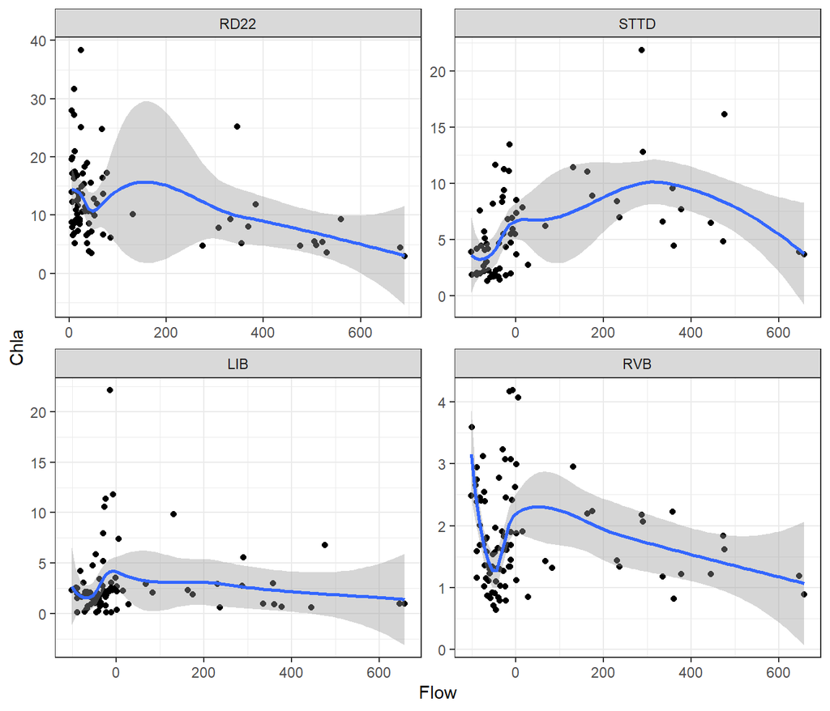

```r
df_chla_c2 %>%
  ggplot(aes(x = Flow, y = Chla)) +
  geom_point() +
  geom_smooth(formula = "y ~ x") +
  facet_wrap(vars(StationCode), scales = "free") +
  theme_bw()
```

At first glance, I’m not sure how well flow is going to be able to predict chlorophyll concentrations. At the furthest upstream station - RD22 - chlorophyll appears to be highest at the lowest flows, but the variation is at its maximum at the lowest flows. There may be some dilution effect going on here at the higher flows. At STTD, there does seem to be a modest increase in chlorophyll concentrations at the mid-range flows. There appears to be no effect of flow on chlorophyll at RVB, but the range of chlorophyll concentrations is narrow at this station (between 0 and 5).

Let’s break these scatterplots apart by year to see how these patterns vary annually.

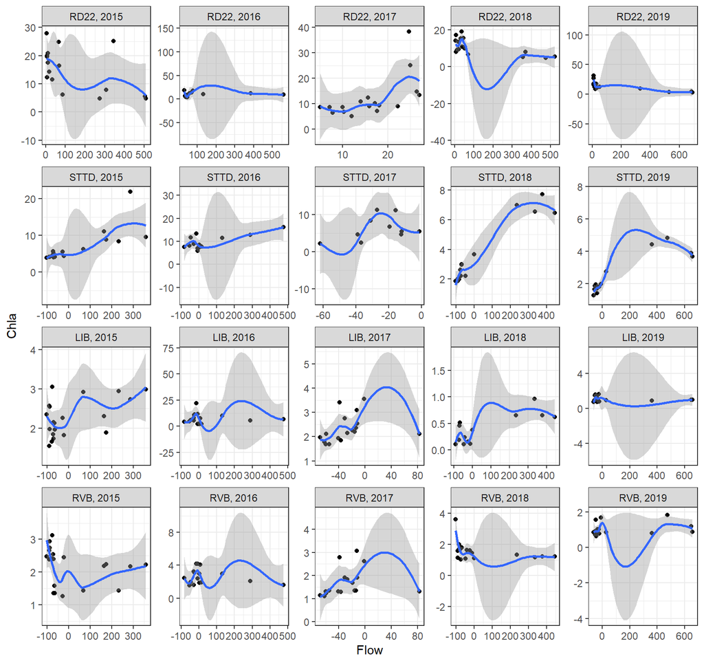

```r
df_chla_c2 %>%
  ggplot(aes(x = Flow, y = Chla)) +
  geom_point() +
  geom_smooth(formula = "y ~ x") +
  facet_wrap(
    vars(StationCode, Year),
    ncol = 5,
    scales = "free",
    labeller = labeller(.multi_line = FALSE)
  ) +
  theme_bw()
```

The patterns appear to vary annually at each station, which may justify using a 3-way interaction.

# Model 1: GAM Model with Flow and 3-way interactions

First, we will attempt to fit a generalized additive model (GAM) to the data set to help account for seasonality in the data. We’ll try running a GAM using a three-way interaction between Year, Weekly Average Flow, and Station, and a cyclic penalized cubic regression spline smooth term for week number to account for seasonality (restricting the k-value to 5 to reduce overfitting). Initially, we’ll run the GAM without accounting for serial autocorrelation.

## Initial Model

```r
m_gam_flow3 <- gam(
  Chla_log ~ Year_fct * Flow * StationCode + s(Week,  bs = "cc", k = 5),
  data = df_chla_c2,
  method = "REML",
  knots = list(week = c(0, 52))
)
```

Lets look at the model summary and diagnostics:

```r
summary(m_gam_flow3)
```

```
##
## Family: gaussian
## Link function: identity
##
## Formula:
## Chla_log ~ Year_fct * Flow * StationCode + s(Week, bs = "cc",
##     k = 5)
##
## Parametric coefficients:
##                                     Estimate Std. Error t value Pr(>|t|)
## (Intercept)                        9.773e+00  1.028e-01  95.030  < 2e-16 ***
## Year_fct2016                      -8.399e-01  1.491e-01  -5.634 4.27e-08 ***
## Year_fct2017                      -9.270e-01  2.299e-01  -4.033 7.10e-05 ***
## Year_fct2018                      -4.121e-01  1.375e-01  -2.997 0.002971 **
## Year_fct2019                      -1.387e-01  1.351e-01  -1.027 0.305445
## Flow                              -1.894e-03  4.583e-04  -4.134 4.71e-05 ***
## StationCodeSTTD                   -1.141e+00  1.296e-01  -8.803  < 2e-16 ***
## StationCodeLIB                    -2.093e+00  1.252e-01 -16.721  < 2e-16 ***
## StationCodeRVB                    -2.139e+00  1.252e-01 -17.086  < 2e-16 ***
## Year_fct2016:Flow                  2.168e-03  7.331e-04   2.957 0.003372 **
## Year_fct2017:Flow                  2.903e-02  1.181e-02   2.458 0.014564 *
## Year_fct2018:Flow                  5.729e-04  6.313e-04   0.908 0.364902
## Year_fct2019:Flow                 -6.888e-05  5.554e-04  -0.124 0.901398
## Year_fct2016:StationCodeSTTD       1.211e+00  1.906e-01   6.353 8.48e-10 ***
## Year_fct2017:StationCodeSTTD       1.141e+00  3.131e-01   3.644 0.000319 ***
## Year_fct2018:StationCodeSTTD      -2.362e-01  1.818e-01  -1.299 0.194995
## Year_fct2019:StationCodeSTTD      -9.179e-01  1.788e-01  -5.133 5.34e-07 ***
## Year_fct2016:StationCodeLIB        1.725e+00  1.836e-01   9.396  < 2e-16 ***
## Year_fct2017:StationCodeLIB        1.032e+00  2.614e-01   3.949 9.94e-05 ***
## Year_fct2018:StationCodeLIB       -1.684e+00  1.831e-01  -9.197  < 2e-16 ***
## Year_fct2019:StationCodeLIB       -5.488e-01  1.782e-01  -3.079 0.002279 **
## Year_fct2016:StationCodeRVB        9.322e-01  1.851e-01   5.037 8.48e-07 ***
## Year_fct2017:StationCodeRVB        7.290e-01  2.614e-01   2.788 0.005658 **
## Year_fct2018:StationCodeRVB        1.103e-01  1.730e-01   0.638 0.524245
## Year_fct2019:StationCodeRVB       -6.620e-01  1.728e-01  -3.831 0.000157 ***
## Flow:StationCodeSTTD               5.195e-03  6.951e-04   7.475 9.86e-13 ***
## Flow:StationCodeLIB                3.302e-03  6.787e-04   4.866 1.90e-06 ***
## Flow:StationCodeRVB                2.240e-03  6.787e-04   3.301 0.001087 **
## Year_fct2016:Flow:StationCodeSTTD -4.430e-03  1.062e-03  -4.173 4.01e-05 ***
## Year_fct2017:Flow:StationCodeSTTD -2.130e-02  1.319e-02  -1.615 0.107370
## Year_fct2018:Flow:StationCodeSTTD -9.922e-04  9.345e-04  -1.062 0.289266
## Year_fct2019:Flow:StationCodeSTTD -1.603e-03  8.273e-04  -1.938 0.053681 .
## Year_fct2016:Flow:StationCodeLIB  -3.443e-03  1.046e-03  -3.293 0.001116 **
## Year_fct2017:Flow:StationCodeLIB  -2.917e-02  1.198e-02  -2.435 0.015531 *
## Year_fct2018:Flow:StationCodeLIB   1.080e-03  9.380e-04   1.151 0.250505
## Year_fct2019:Flow:StationCodeLIB  -1.223e-03  8.241e-04  -1.485 0.138753
## Year_fct2016:Flow:StationCodeRVB  -3.292e-03  1.048e-03  -3.142 0.001855 **
## Year_fct2017:Flow:StationCodeRVB  -2.807e-02  1.198e-02  -2.343 0.019847 *
## Year_fct2018:Flow:StationCodeRVB  -1.138e-03  9.159e-04  -1.242 0.215225
## Year_fct2019:Flow:StationCodeRVB   3.417e-04  8.116e-04   0.421 0.674054
## ---
## Signif. codes:  0 '***' 0.001 '**' 0.01 '*' 0.05 '.' 0.1 ' ' 1
##
## Approximate significance of smooth terms:
##           edf Ref.df     F p-value
## s(Week) 2.729      3 24.69  <2e-16 ***
## ---
## Signif. codes:  0 '***' 0.001 '**' 0.01 '*' 0.05 '.' 0.1 ' ' 1
##
## R-sq.(adj) =  0.908   Deviance explained =   92%
## -REML =  233.8  Scale est. = 0.10226   n = 324
```

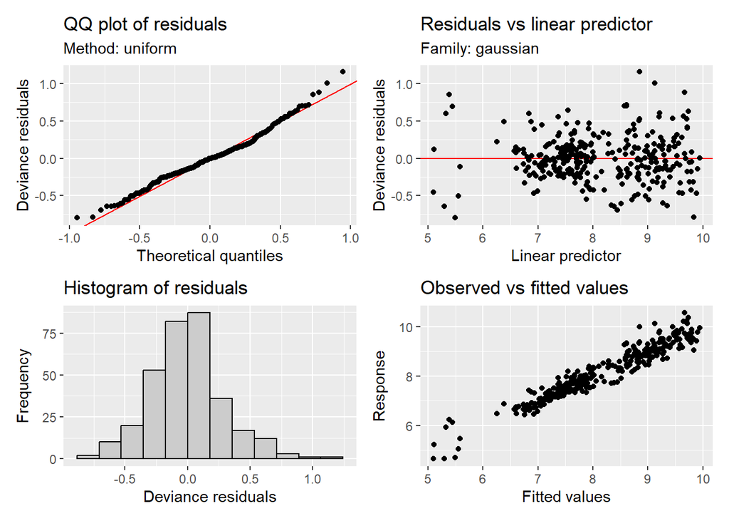

```r
appraise(m_gam_flow3)
```

```r
shapiro.test(residuals(m_gam_flow3))
```

```
##
##  Shapiro-Wilk normality test
##
## data:  residuals(m_gam_flow3)
## W = 0.98296, p-value = 0.000692
```

```r
k.check(m_gam_flow3)
```

```
##         k'      edf   k-index p-value
## s(Week)  3 2.729041 0.9270647  0.0625
```

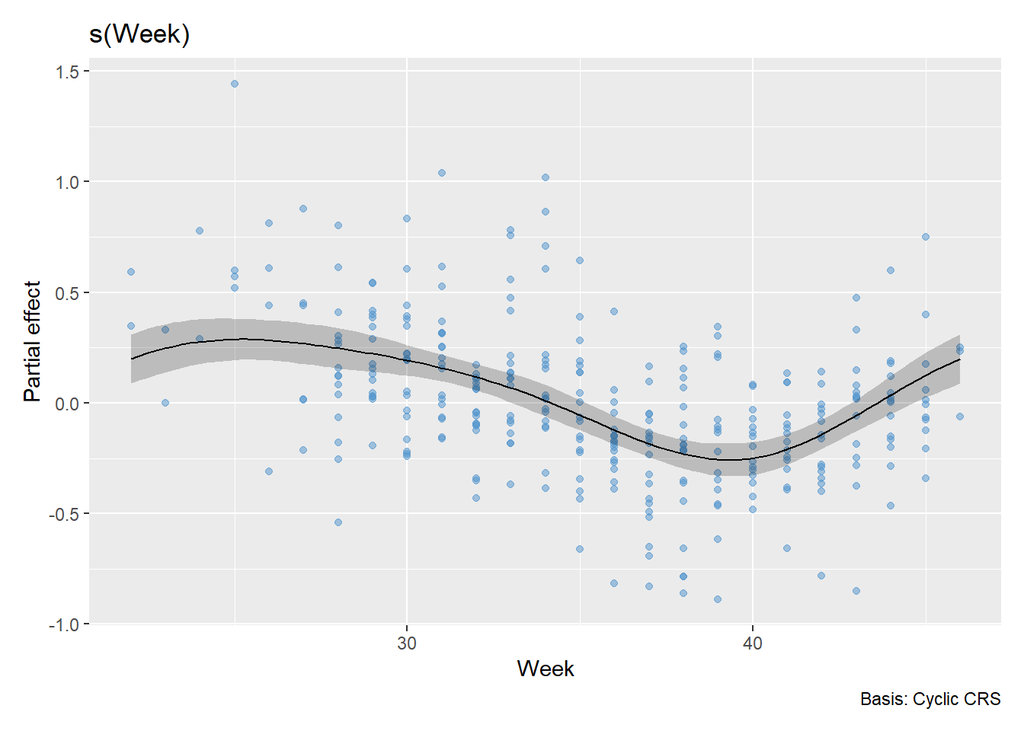

```r
draw(m_gam_flow3, select = 1, residuals = TRUE, rug = FALSE)
```

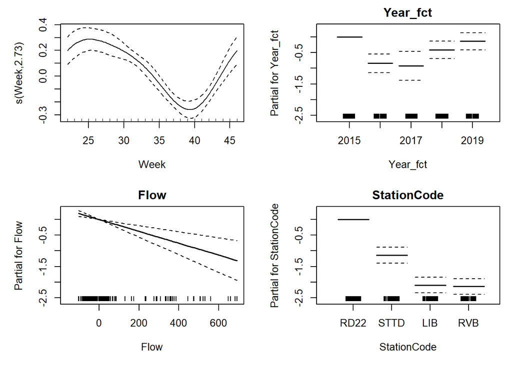

```r
plot(m_gam_flow3, pages = 1, all.terms = TRUE)
```

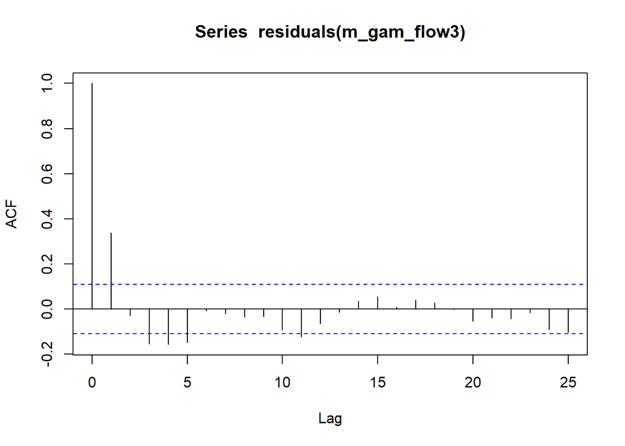

```r
acf(residuals(m_gam_flow3))
```

```r
Box.test(residuals(m_gam_flow3), lag = 20, type = 'Ljung-Box')
```

```
##
##  Box-Ljung test
##
## data:  residuals(m_gam_flow3)
## X-squared = 74.642, df = 20, p-value = 3.125e-08
```

Besides the Shapiro-Wilk normality test showing that the residuals aren’t normal, the diagnostic plots look pretty good. However, the residuals are autocorrelated.

## Model with lag terms

Now, we’ll try to deal with the residual autocorrelation. We’ll run a series of models adding 1 and 2 lag terms and compare how well they correct for autocorrelation.

### Lag 1

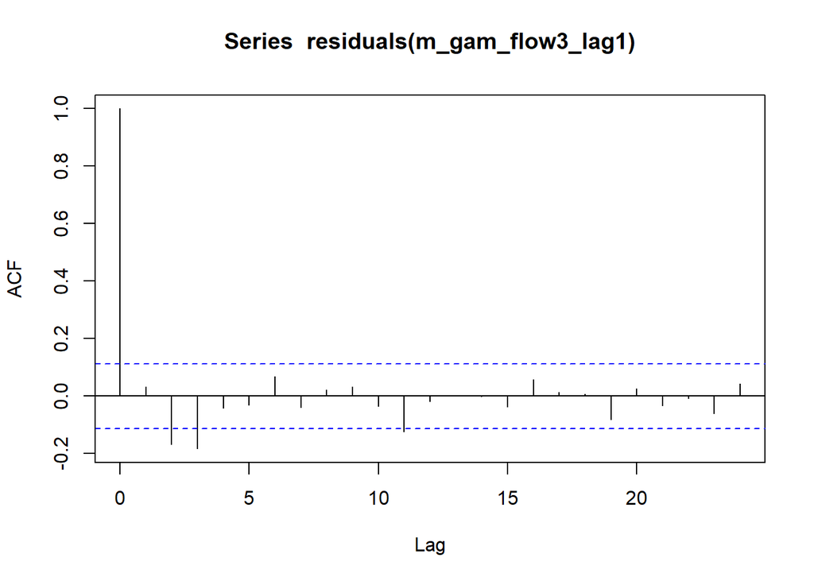

```r
m_gam_flow3_lag1 <- gam(
  Chla_log ~ Year_fct * Flow * StationCode + s(Week, bs = "cc", k = 5) + lag1,
  data = df_chla_c2_lag,
  method = "REML",
  knots = list(week = c(0, 52))
)

acf(residuals(m_gam_flow3_lag1))
```

```r
Box.test(residuals(m_gam_flow3_lag1), lag = 20, type = 'Ljung-Box')
```

```
##
##  Box-Ljung test
##
## data:  residuals(m_gam_flow3_lag1)
## X-squared = 32.024, df = 20, p-value = 0.04305
```

### Lag 2

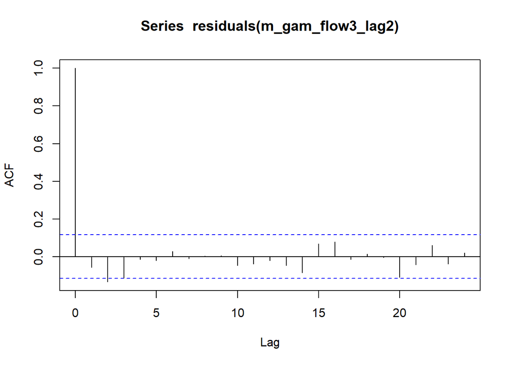

```r
m_gam_flow3_lag2 <- gam(
  Chla_log ~ Year_fct * Flow * StationCode + s(Week, bs = "cc", k = 5) + lag1 + lag2,
  data = df_chla_c2_lag,
  method = "REML",
  knots = list(week = c(0, 52))
)

acf(residuals(m_gam_flow3_lag2))
```

```r
Box.test(residuals(m_gam_flow3_lag2), lag = 20, type = 'Ljung-Box')
```

```
##
##  Box-Ljung test
##
## data:  residuals(m_gam_flow3_lag2)
## X-squared = 21.5, df = 20, p-value = 0.3682
```

### Compare Models

```r
AIC(m_gam_flow3, m_gam_flow3_lag1, m_gam_flow3_lag2)
```

```
##                        df      AIC
## m_gam_flow3      43.93936 222.7229
## m_gam_flow3_lag1 44.80311 143.9646
## m_gam_flow3_lag2 45.70977 136.0963
```

It looks like the lag2 model has the best fit according to the AIC values. Let’s take a closer look at that one.

### Lag 2 model summary

```r
summary(m_gam_flow3_lag2)
```

```
##
## Family: gaussian
## Link function: identity
##
## Formula:
## Chla_log ~ Year_fct * Flow * StationCode + s(Week, bs = "cc",
##     k = 5) + lag1 + lag2
##
## Parametric coefficients:
##                                     Estimate Std. Error t value Pr(>|t|)
## (Intercept)                        6.457e+00  5.381e-01  11.999  < 2e-16 ***
## Year_fct2016                      -6.040e-01  1.522e-01  -3.968 9.60e-05 ***
## Year_fct2017                      -7.041e-01  2.304e-01  -3.056 0.002493 **
## Year_fct2018                      -3.195e-01  1.358e-01  -2.353 0.019429 *
## Year_fct2019                      -7.442e-02  1.324e-01  -0.562 0.574628
## Flow                              -1.378e-03  4.361e-04  -3.159 0.001788 **
## StationCodeSTTD                   -7.493e-01  1.379e-01  -5.435 1.35e-07 ***
## StationCodeLIB                    -1.427e+00  1.606e-01  -8.885  < 2e-16 ***
## StationCodeRVB                    -1.448e+00  1.640e-01  -8.831 2.24e-16 ***
## lag1                               4.422e-01  6.280e-02   7.042 2.00e-11 ***
## lag2                              -1.029e-01  5.679e-02  -1.811 0.071338 .
## Year_fct2016:Flow                  1.388e-03  6.872e-04   2.020 0.044463 *
## Year_fct2017:Flow                  2.475e-02  1.293e-02   1.914 0.056806 .
## Year_fct2018:Flow                  6.146e-04  5.818e-04   1.056 0.291879
## Year_fct2019:Flow                  9.183e-05  5.150e-04   0.178 0.858623
## Year_fct2016:StationCodeSTTD       8.625e-01  1.949e-01   4.425 1.47e-05 ***
## Year_fct2017:StationCodeSTTD       8.917e-01  3.137e-01   2.842 0.004863 **
## Year_fct2018:StationCodeSTTD      -6.823e-02  1.796e-01  -0.380 0.704387
## Year_fct2019:StationCodeSTTD      -6.332e-01  1.825e-01  -3.469 0.000619 ***
## Year_fct2016:StationCodeLIB        1.197e+00  2.007e-01   5.962 8.85e-09 ***
## Year_fct2017:StationCodeLIB        7.846e-01  2.598e-01   3.020 0.002802 **
## Year_fct2018:StationCodeLIB       -1.223e+00  2.077e-01  -5.888 1.31e-08 ***
## Year_fct2019:StationCodeLIB       -3.807e-01  1.783e-01  -2.135 0.033762 *
## Year_fct2016:StationCodeRVB        6.358e-01  1.861e-01   3.417 0.000744 ***
## Year_fct2017:StationCodeRVB        5.530e-01  2.569e-01   2.153 0.032349 *
## Year_fct2018:StationCodeRVB        1.523e-01  1.681e-01   0.906 0.366035
## Year_fct2019:StationCodeRVB       -4.260e-01  1.730e-01  -2.463 0.014498 *
## Flow:StationCodeSTTD               3.504e-03  6.822e-04   5.137 5.79e-07 ***
## Flow:StationCodeLIB                2.591e-03  6.383e-04   4.059 6.67e-05 ***
## Flow:StationCodeRVB                1.672e-03  6.328e-04   2.643 0.008770 **
```

[output cut: 8 more lines]

```
## Year_fct2016:Flow:StationCodeRVB  -2.092e-03  9.709e-04  -2.155 0.032182 *
## Year_fct2017:Flow:StationCodeRVB  -2.403e-02  1.303e-02  -1.844 0.066479 .
## Year_fct2018:Flow:StationCodeRVB  -1.105e-03  8.418e-04  -1.313 0.190473
## Year_fct2019:Flow:StationCodeRVB  -5.663e-05  7.480e-04  -0.076 0.939710
## ---
## Signif. codes:  0 '***' 0.001 '**' 0.01 '*' 0.05 '.' 0.1 ' ' 1
##
## Approximate significance of smooth terms:
##           edf Ref.df     F p-value
## s(Week) 2.492      3 11.75  <2e-16 ***
## ---
## Signif. codes:  0 '***' 0.001 '**' 0.01 '*' 0.05 '.' 0.1 ' ' 1
##
## R-sq.(adj) =  0.928   Deviance explained = 93.9%
## -REML = 194.53  Scale est. = 0.081254  n = 284
```

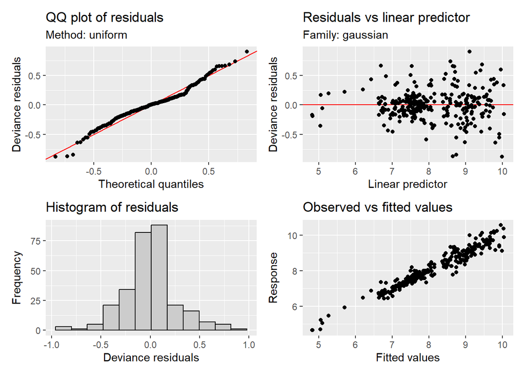

```r
appraise(m_gam_flow3_lag2)
```

```r
shapiro.test(residuals(m_gam_flow3_lag2))
```

```
##
##  Shapiro-Wilk normality test
##
## data:  residuals(m_gam_flow3_lag2)
## W = 0.97077, p-value = 1.533e-05
```

```r
k.check(m_gam_flow3_lag2)
```

```
##         k'      edf   k-index p-value
## s(Week)  3 2.492179 0.9184442   0.065
```

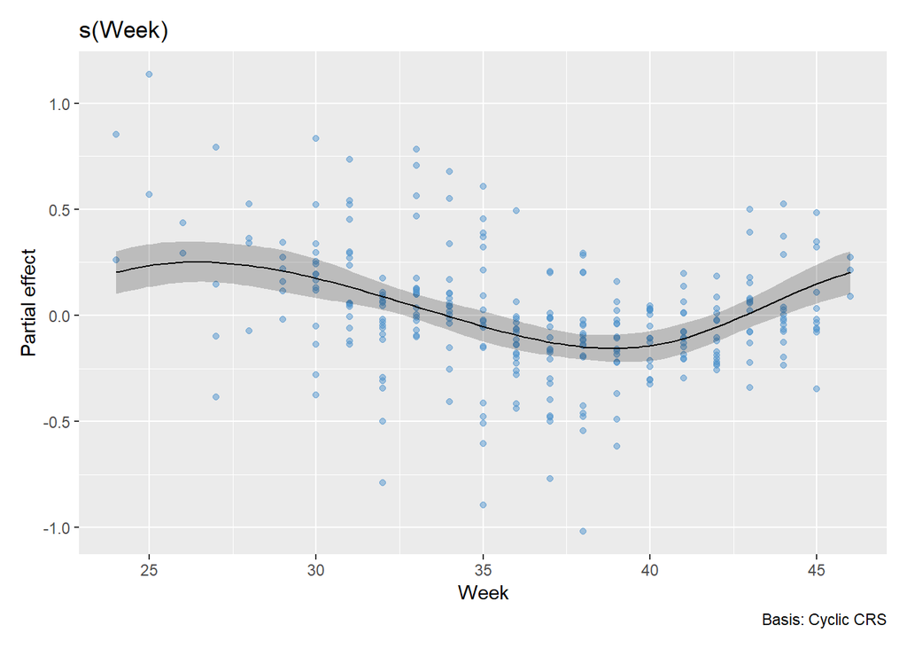

```r
draw(m_gam_flow3_lag2, select = 1, residuals = TRUE, rug = FALSE)
```

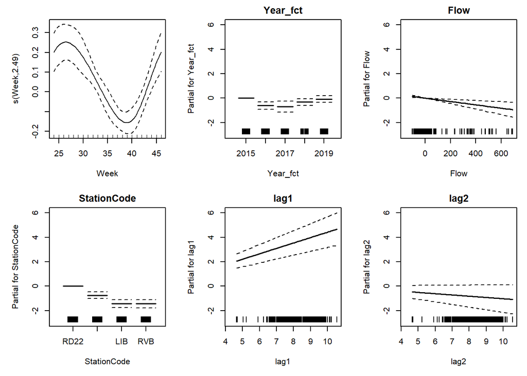

```r
plot(m_gam_flow3_lag2, pages = 1, all.terms = TRUE)
```

```r
anova(m_gam_flow3_lag2)
```

```
##
## Family: gaussian
## Link function: identity
##
## Formula:
## Chla_log ~ Year_fct * Flow * StationCode + s(Week, bs = "cc",
##     k = 5) + lag1 + lag2
##
## Parametric Terms:
##                           df      F  p-value
## Year_fct                   4  6.153 9.94e-05
## Flow                       1  9.978  0.00179
## StationCode                3 30.183  < 2e-16
## lag1                       1 49.587 2.00e-11
## lag2                       1  3.281  0.07134
## Year_fct:Flow              4  2.202  0.06948
## Year_fct:StationCode      12  8.790 7.17e-14
## Flow:StationCode           3 10.049 2.92e-06
## Year_fct:Flow:StationCode 12  2.584  0.00304
##
## Approximate significance of smooth terms:
##           edf Ref.df     F p-value
## s(Week) 2.492  3.000 11.75  <2e-16
```

The model diagnostics look pretty good. Note that the 2-way interaction between Year and Flow isn’t significant. We’ll use `m_gam_flow3_lag2` in the model selection process.

```r
rm(m_gam_flow3, m_gam_flow3_lag1)
```

# Model 2: GAM Model with Flow and 2-way interactions

Now we’ll try running a GAM using all two-way interactions between Year, Flow, and Station.

## Initial Model

```r
m_gam_flow2 <- gam(
  Chla_log ~ (Year_fct + Flow + StationCode)^2 + s(Week, bs = "cc", k = 5),
  data = df_chla_c2,
  method = "REML",
  knots = list(week = c(0, 52))
)
```

Lets look at the model summary and diagnostics:

```r
summary(m_gam_flow2)
```

```
##
## Family: gaussian
## Link function: identity
##
## Formula:
## Chla_log ~ (Year_fct + Flow + StationCode)^2 + s(Week, bs = "cc",
##     k = 5)
##
## Parametric coefficients:
##                                Estimate Std. Error t value Pr(>|t|)
## (Intercept)                   9.6785347  0.0976557  99.109  < 2e-16 ***
## Year_fct2016                 -0.5160117  0.1363411  -3.785 0.000187 ***
## Year_fct2017                 -0.3917242  0.1302573  -3.007 0.002864 **
## Year_fct2018                 -0.3677308  0.1268303  -2.899 0.004021 **
## Year_fct2019                 -0.0645713  0.1259576  -0.513 0.608587
## Flow                         -0.0011879  0.0003373  -3.522 0.000497 ***
## StationCodeSTTD              -1.0148358  0.1264555  -8.025 2.46e-14 ***
## StationCodeLIB               -1.9983265  0.1229774 -16.250  < 2e-16 ***
## StationCodeRVB               -2.0473550  0.1229570 -16.651  < 2e-16 ***
## Year_fct2016:Flow            -0.0006402  0.0004252  -1.505 0.133281
## Year_fct2017:Flow             0.0012378  0.0017088   0.724 0.469434
## Year_fct2018:Flow             0.0003011  0.0003586   0.839 0.401889
## Year_fct2019:Flow            -0.0006212  0.0003201  -1.941 0.053260 .
## Year_fct2016:StationCodeSTTD  0.8092426  0.1800566   4.494 1.01e-05 ***
## Year_fct2017:StationCodeSTTD  0.3774412  0.1999526   1.888 0.060060 .
## Year_fct2018:StationCodeSTTD -0.3032110  0.1740797  -1.742 0.082593 .
## Year_fct2019:StationCodeSTTD -1.0386379  0.1709584  -6.075 3.83e-09 ***
## Year_fct2016:StationCodeLIB   1.3710722  0.1745109   7.857 7.53e-14 ***
## Year_fct2017:StationCodeLIB   0.5334927  0.1846843   2.889 0.004157 **
## Year_fct2018:StationCodeLIB  -1.6107835  0.1741979  -9.247  < 2e-16 ***
## Year_fct2019:StationCodeLIB  -0.6746411  0.1723851  -3.914 0.000113 ***
## Year_fct2016:StationCodeRVB   0.5745856  0.1757651   3.269 0.001208 **
## Year_fct2017:StationCodeRVB   0.2096231  0.1846195   1.135 0.257121
## Year_fct2018:StationCodeRVB   0.0386979  0.1668655   0.232 0.816769
## Year_fct2019:StationCodeRVB  -0.6665100  0.1664704  -4.004 7.90e-05 ***
## Flow:StationCodeSTTD          0.0036351  0.0003199  11.364  < 2e-16 ***
## Flow:StationCodeLIB           0.0025172  0.0003265   7.709 1.98e-13 ***
## Flow:StationCodeRVB           0.0016994  0.0003164   5.371 1.60e-07 ***
## ---
## Signif. codes:  0 '***' 0.001 '**' 0.01 '*' 0.05 '.' 0.1 ' ' 1
##
## Approximate significance of smooth terms:
##           edf Ref.df     F p-value
## s(Week) 2.713      3 27.04  <2e-16 ***
## ---
## Signif. codes:  0 '***' 0.001 '**' 0.01 '*' 0.05 '.' 0.1 ' ' 1
##
## R-sq.(adj) =  0.894   Deviance explained = 90.4%
## -REML = 190.64  Scale est. = 0.11725   n = 324
```

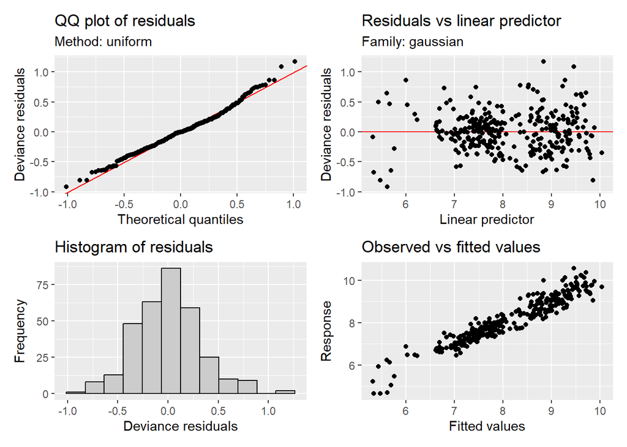

```r
appraise(m_gam_flow2)
```

```r
shapiro.test(residuals(m_gam_flow2))
```

```
##
##  Shapiro-Wilk normality test
##
## data:  residuals(m_gam_flow2)
## W = 0.9887, p-value = 0.01281
```

```r
k.check(m_gam_flow2)
```

```
##         k'      edf   k-index p-value
## s(Week)  3 2.713176 0.9526447   0.165
```

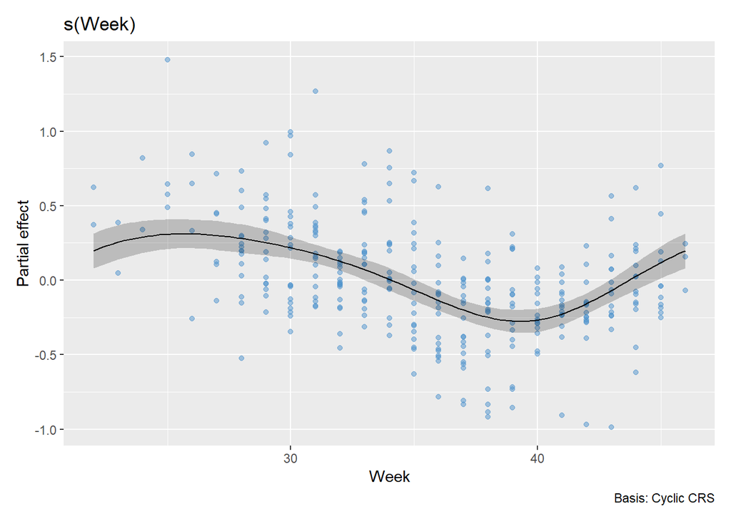

```r
draw(m_gam_flow2, select = 1, residuals = TRUE, rug = FALSE)
```

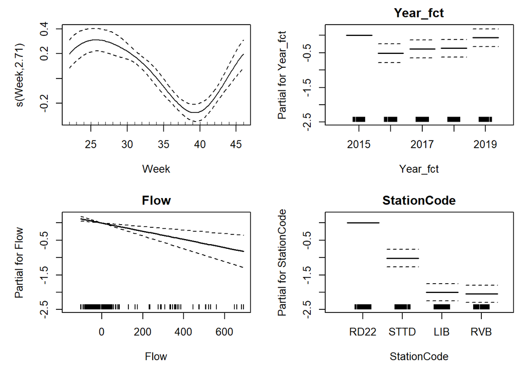

```r
plot(m_gam_flow2, pages = 1, all.terms = TRUE)
```

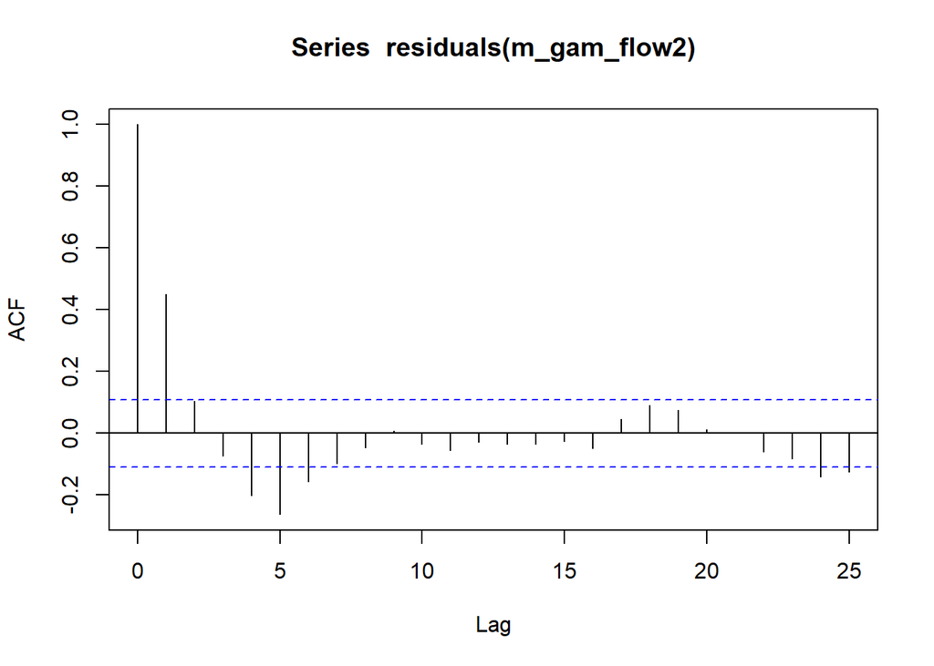

```r
acf(residuals(m_gam_flow2))
```

```r
Box.test(residuals(m_gam_flow2), lag = 20, type = 'Ljung-Box')
```

```
##
##  Box-Ljung test
##
## data:  residuals(m_gam_flow2)
## X-squared = 129.09, df = 20, p-value < 2.2e-16
```

Besides the Shapiro-Wilk normality test showing that the residuals aren’t normal, the diagnostic plots look really good. However, the residuals are autocorrelated.

## Model with lag terms

Now, we’ll try to deal with the residual autocorrelation. We’ll run a series of models adding 1 and 2 lag terms and compare how well they correct for autocorrelation.

### Lag 1

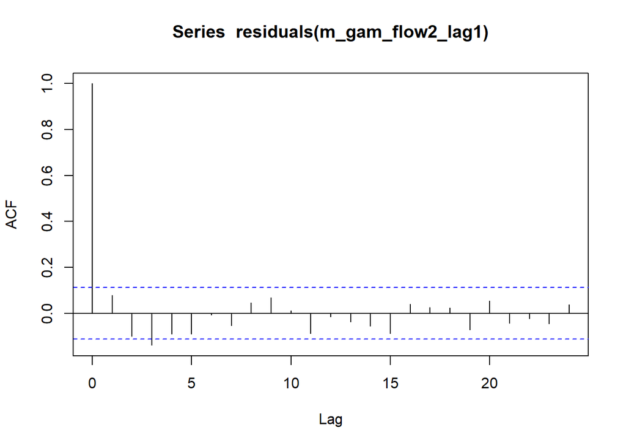

```r
m_gam_flow2_lag1 <- gam(
  Chla_log ~ (Year_fct + Flow + StationCode)^2 + s(Week, bs = "cc", k = 5) + lag1,
  data = df_chla_c2_lag,
  method = "REML",
  knots = list(week = c(0, 52))
)

acf(residuals(m_gam_flow2_lag1))
```

```r
Box.test(residuals(m_gam_flow2_lag1), lag = 20, type = 'Ljung-Box')
```

```
##
##  Box-Ljung test
##
## data:  residuals(m_gam_flow2_lag1)
## X-squared = 29.001, df = 20, p-value = 0.08773
```

### Lag 2

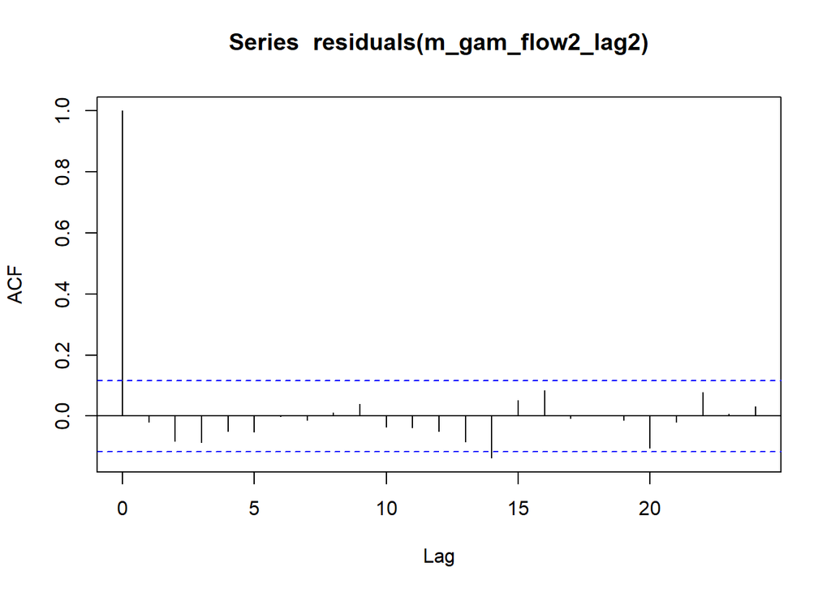

```r
m_gam_flow2_lag2 <- gam(
  Chla_log ~ (Year_fct + Flow + StationCode)^2 + s(Week, bs = "cc", k = 5) + lag1 + lag2,
  data = df_chla_c2_lag,
  method = "REML",
  knots = list(week = c(0, 52))
)

acf(residuals(m_gam_flow2_lag2))
```

```r
Box.test(residuals(m_gam_flow2_lag2), lag = 20, type = 'Ljung-Box')
```

```
##
##  Box-Ljung test
##
## data:  residuals(m_gam_flow2_lag2)
## X-squared = 21.766, df = 20, p-value = 0.3533
```

The model with 1 lag term already seems to address the serial autocorrelation, but the lag2 model is even better. Let’s use AIC to see how they compare.

### Compare Models

```r
AIC(m_gam_flow2, m_gam_flow2_lag1, m_gam_flow2_lag2)
```

```
##                        df      AIC
## m_gam_flow2      31.89629 256.5089
## m_gam_flow2_lag1 32.76250 150.1410
## m_gam_flow2_lag2 33.67624 146.9387
```

Again, it looks like the lag2 model has the best fit according to the AIC values. Let’s take a closer look at that one.

### Lag 2 model summary

```r
summary(m_gam_flow2_lag2)
```

```
##
## Family: gaussian
## Link function: identity
##
## Formula:
## Chla_log ~ (Year_fct + Flow + StationCode)^2 + s(Week, bs = "cc",
##     k = 5) + lag1 + lag2
##
## Parametric coefficients:
##                                Estimate Std. Error t value Pr(>|t|)
## (Intercept)                   5.3662016  0.5043957  10.639  < 2e-16 ***
## Year_fct2016                 -0.3297933  0.1311038  -2.516 0.012510 *
## Year_fct2017                 -0.2414980  0.1222049  -1.976 0.049228 *
## Year_fct2018                 -0.2301478  0.1196736  -1.923 0.055593 .
## Year_fct2019                  0.0109322  0.1177270   0.093 0.926088
## Flow                         -0.0007624  0.0003112  -2.450 0.014958 *
## StationCodeSTTD              -0.5388663  0.1257449  -4.285 2.60e-05 ***
## StationCodeLIB               -1.1379329  0.1497928  -7.597 5.98e-13 ***
## StationCodeRVB               -1.1542962  0.1527487  -7.557 7.68e-13 ***
## lag1                          0.5463245  0.0617008   8.854  < 2e-16 ***
## lag2                         -0.1017626  0.0571666  -1.780 0.076266 .
## Year_fct2016:Flow            -0.0003588  0.0004033  -0.890 0.374502
## Year_fct2017:Flow             0.0006436  0.0015057   0.427 0.669422
## Year_fct2018:Flow             0.0003122  0.0003217   0.970 0.332888
## Year_fct2019:Flow            -0.0003463  0.0002888  -1.199 0.231698
## Year_fct2016:StationCodeSTTD  0.4844492  0.1705394   2.841 0.004870 **
## Year_fct2017:StationCodeSTTD  0.2241941  0.1866201   1.201 0.230749
## Year_fct2018:StationCodeSTTD -0.1270279  0.1612103  -0.788 0.431460
## Year_fct2019:StationCodeSTTD -0.6331731  0.1651007  -3.835 0.000159 ***
## Year_fct2016:StationCodeLIB   0.7928280  0.1755833   4.515 9.72e-06 ***
## Year_fct2017:StationCodeLIB   0.3290977  0.1698532   1.938 0.053798 .
## Year_fct2018:StationCodeLIB  -0.9598305  0.1821609  -5.269 2.95e-07 ***
## Year_fct2019:StationCodeLIB  -0.4498340  0.1628288  -2.763 0.006157 **
## Year_fct2016:StationCodeRVB   0.3314845  0.1650767   2.008 0.045706 *
## Year_fct2017:StationCodeRVB   0.1085885  0.1685921   0.644 0.520104
## Year_fct2018:StationCodeRVB   0.0609466  0.1532752   0.398 0.691241
## Year_fct2019:StationCodeRVB  -0.3872854  0.1563890  -2.476 0.013929 *
## Flow:StationCodeSTTD          0.0020916  0.0003174   6.589 2.57e-10 ***
## Flow:StationCodeLIB           0.0016824  0.0003057   5.503 9.17e-08 ***
## Flow:StationCodeRVB           0.0009565  0.0002892   3.308 0.001079 **
## ---
## Signif. codes:  0 '***' 0.001 '**' 0.01 '*' 0.05 '.' 0.1 ' ' 1
##
## Approximate significance of smooth terms:
##           edf Ref.df     F  p-value
## s(Week) 2.433      3 10.13 9.24e-07 ***
## ---
## Signif. codes:  0 '***' 0.001 '**' 0.01 '*' 0.05 '.' 0.1 ' ' 1
##
## R-sq.(adj) =  0.922   Deviance explained = 93.1%
## -REML = 139.63  Scale est. = 0.087477  n = 284
```

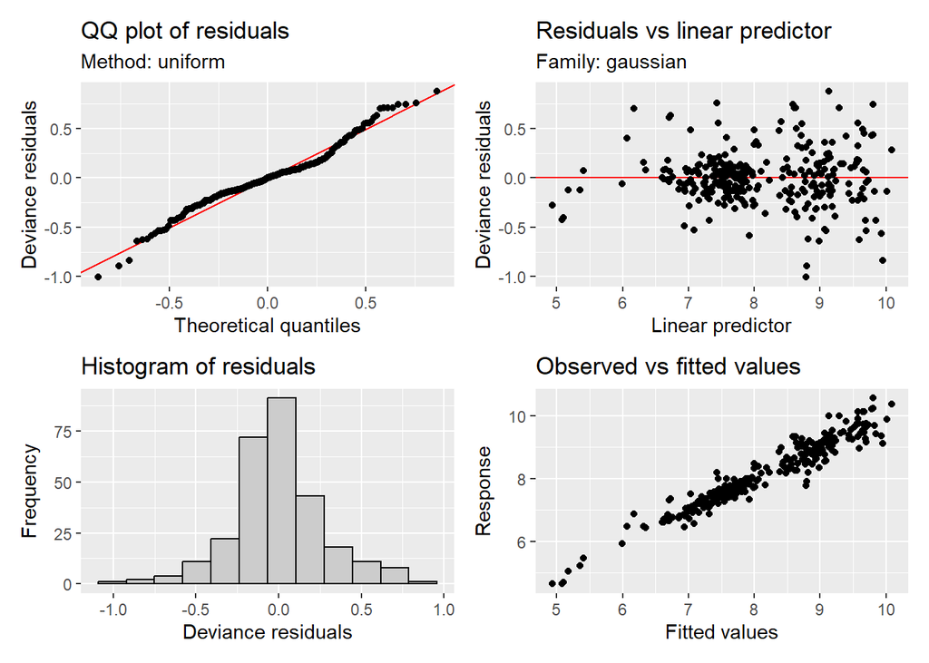

```r
appraise(m_gam_flow2_lag2)
```

```r
shapiro.test(residuals(m_gam_flow2_lag2))
```

```
##
##  Shapiro-Wilk normality test
##
## data:  residuals(m_gam_flow2_lag2)
## W = 0.96771, p-value = 5.379e-06
```

```r
k.check(m_gam_flow2_lag2)
```

```
##         k'      edf  k-index p-value
## s(Week)  3 2.433331 0.953256    0.25
```

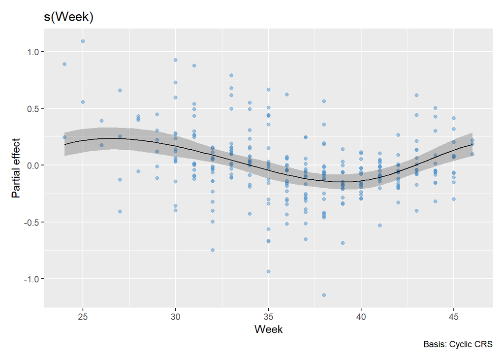

```r
draw(m_gam_flow2_lag2, select = 1, residuals = TRUE, rug = FALSE)
```

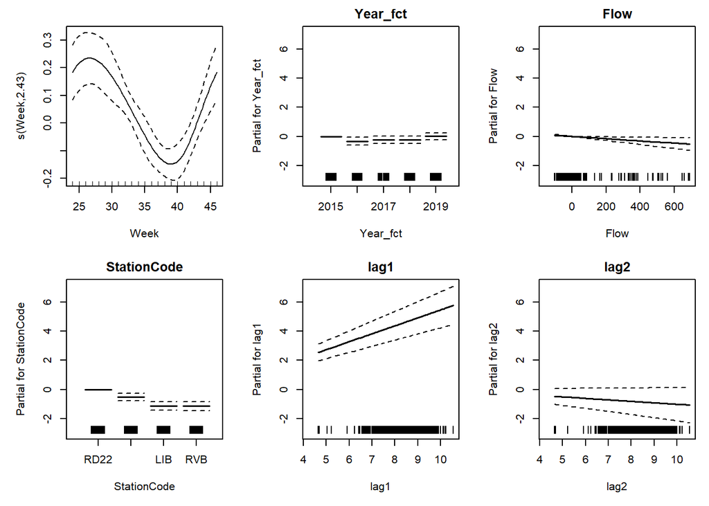

```r
plot(m_gam_flow2_lag2, pages = 1, all.terms = TRUE)
```

```r
anova(m_gam_flow2_lag2)
```

```
##
## Family: gaussian
## Link function: identity
##
## Formula:
## Chla_log ~ (Year_fct + Flow + StationCode)^2 + s(Week, bs = "cc",
##     k = 5) + lag1 + lag2
##
## Parametric Terms:
##                      df      F  p-value
## Year_fct              4  3.083   0.0167
## Flow                  1  6.004   0.0150
## StationCode           3 22.412 6.81e-13
## lag1                  1 78.401  < 2e-16
## lag2                  1  3.169   0.0763
## Year_fct:Flow         4  1.761   0.1372
## Year_fct:StationCode 12  6.748 1.63e-10
## Flow:StationCode      3 16.615 7.02e-10
##
## Approximate significance of smooth terms:
##           edf Ref.df     F  p-value
## s(Week) 2.433  3.000 10.13 9.24e-07
```

The model diagnostics look pretty good. Note that the 2-way interaction between Year and Flow isn’t significant. We’ll use `m_gam_flow2_lag2` in the model selection process.

```r
rm(m_gam_flow2, m_gam_flow2_lag1)
```

# Model 3: GAM Model with 2-way interaction between Station and Year but without Flow

Next we’ll try running a GAM using a two-way interaction between Year and Station but not including flow as a predictor.

## Initial Model

```r
m_gam_cat2 <- gam(
  Chla_log ~ Year_fct * StationCode + s(Week, bs = "cc", k = 5),
  data = df_chla_c2,
  method = "REML",
  knots = list(week = c(0, 52))
)
```

Lets look at the model summary and diagnostics:

```r
summary(m_gam_cat2)
```

```
##
## Family: gaussian
## Link function: identity
##
## Formula:
## Chla_log ~ Year_fct * StationCode + s(Week, bs = "cc", k = 5)
##
## Parametric coefficients:
##                              Estimate Std. Error t value Pr(>|t|)
## (Intercept)                   9.50143    0.10544  90.116  < 2e-16 ***
## Year_fct2016                 -0.53966    0.15556  -3.469 0.000598 ***
## Year_fct2017                 -0.22139    0.14665  -1.510 0.132184
## Year_fct2018                 -0.29804    0.14461  -2.061 0.040157 *
## Year_fct2019                 -0.14458    0.14461  -1.000 0.318217
## StationCodeSTTD              -0.76504    0.14652  -5.222 3.31e-07 ***
## StationCodeLIB               -1.79713    0.14133 -12.716  < 2e-16 ***
## StationCodeRVB               -1.85708    0.14133 -13.140  < 2e-16 ***
## Year_fct2016:StationCodeSTTD  0.85168    0.21617   3.940 0.000101 ***
## Year_fct2017:StationCodeSTTD  0.03124    0.22324   0.140 0.888793
## Year_fct2018:StationCodeSTTD -0.32807    0.20996  -1.563 0.119213
## Year_fct2019:StationCodeSTTD -0.84839    0.20587  -4.121 4.88e-05 ***
## Year_fct2016:StationCodeLIB   1.41976    0.20751   6.842 4.36e-11 ***
## Year_fct2017:StationCodeLIB   0.26021    0.20194   1.289 0.198535
## Year_fct2018:StationCodeLIB  -1.59497    0.20924  -7.623 3.26e-13 ***
## Year_fct2019:StationCodeLIB  -0.55049    0.20608  -2.671 0.007968 **
## Year_fct2016:StationCodeRVB   0.60877    0.20905   2.912 0.003859 **
## Year_fct2017:StationCodeRVB  -0.03003    0.20194  -0.149 0.881876
## Year_fct2018:StationCodeRVB  -0.02211    0.19905  -0.111 0.911619
## Year_fct2019:StationCodeRVB  -0.61209    0.19905  -3.075 0.002298 **
## ---
## Signif. codes:  0 '***' 0.001 '**' 0.01 '*' 0.05 '.' 0.1 ' ' 1
##
## Approximate significance of smooth terms:
##           edf Ref.df     F p-value
## s(Week) 2.515      3 14.88  <2e-16 ***
## ---
## Signif. codes:  0 '***' 0.001 '**' 0.01 '*' 0.05 '.' 0.1 ' ' 1
##
## R-sq.(adj) =   0.84   Deviance explained = 85.1%
## -REML = 199.37  Scale est. = 0.17683   n = 324
```

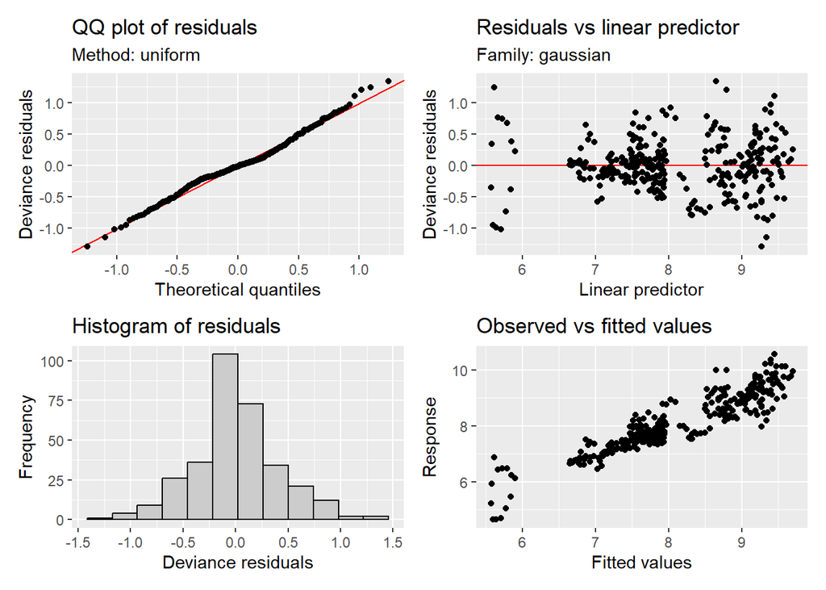

```r
appraise(m_gam_cat2)
```

```r
shapiro.test(residuals(m_gam_cat2))
```

```
##
##  Shapiro-Wilk normality test
##
## data:  residuals(m_gam_cat2)
## W = 0.98654, p-value = 0.004115
```

```r
k.check(m_gam_cat2)
```

```
##         k'      edf   k-index p-value
## s(Week)  3 2.515323 0.9266828  0.0925
```

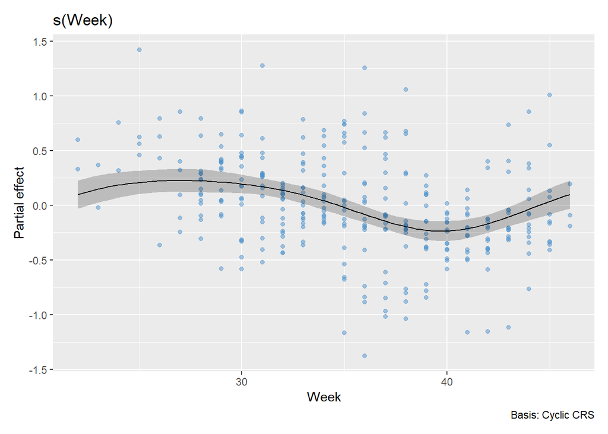

```r
draw(m_gam_cat2, select = 1, residuals = TRUE, rug = FALSE)
```

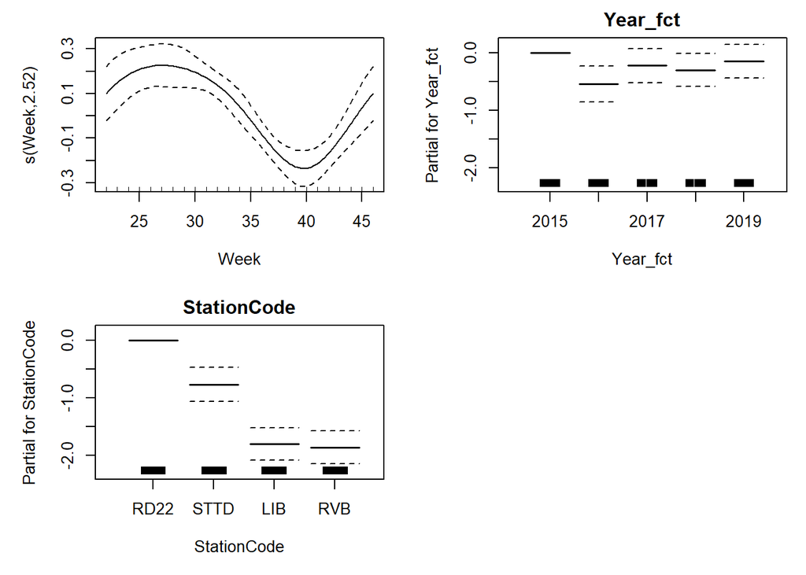

```r
plot(m_gam_cat2, pages = 1, all.terms = TRUE)
```

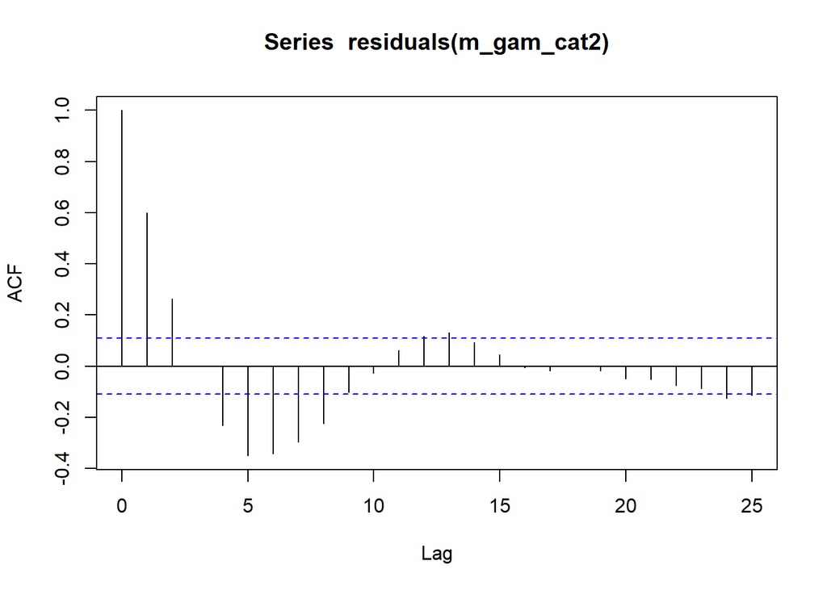

```r
acf(residuals(m_gam_cat2))
```

```r
Box.test(residuals(m_gam_cat2), lag = 20, type = 'Ljung-Box')
```

```
##
##  Box-Ljung test
##
## data:  residuals(m_gam_cat2)
## X-squared = 304.27, df = 20, p-value < 2.2e-16
```

Besides the Shapiro-Wilk normality test showing that the residuals aren’t normal, the diagnostic plots look really good. However, the residuals are autocorrelated.

## Model with lag terms

Now, we’ll try to deal with the residual autocorrelation. We’ll run a series of models adding 1 and 2 lag terms and compare how well they correct for autocorrelation.

### Lag 1

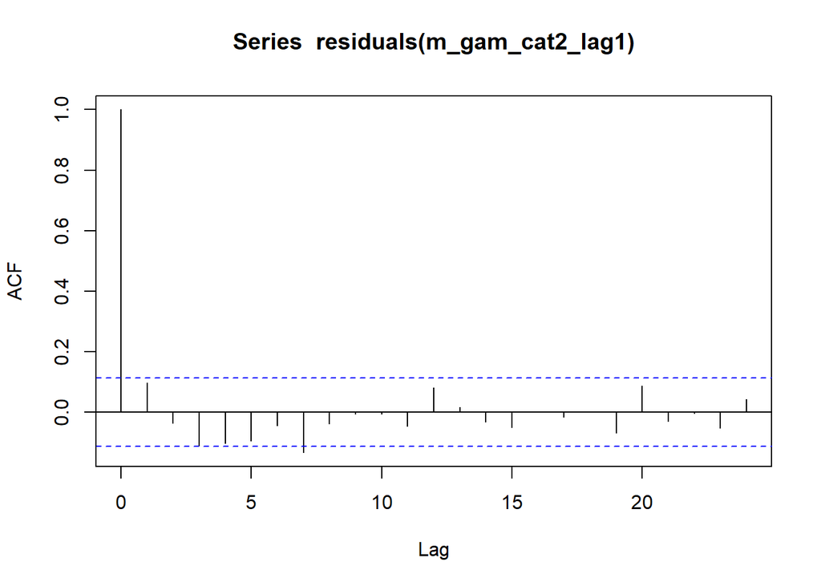

```r
m_gam_cat2_lag1 <- gam(
  Chla_log ~ Year_fct * StationCode + s(Week, bs = "cc", k = 5) + lag1,
  data = df_chla_c2_lag,
  method = "REML",
  knots = list(week = c(0, 52))
)

acf(residuals(m_gam_cat2_lag1))
```

```r
Box.test(residuals(m_gam_cat2_lag1), lag = 20, type = 'Ljung-Box')
```

```
##
##  Box-Ljung test
##
## data:  residuals(m_gam_cat2_lag1)
## X-squared = 27.997, df = 20, p-value = 0.1095
```

### Lag 2

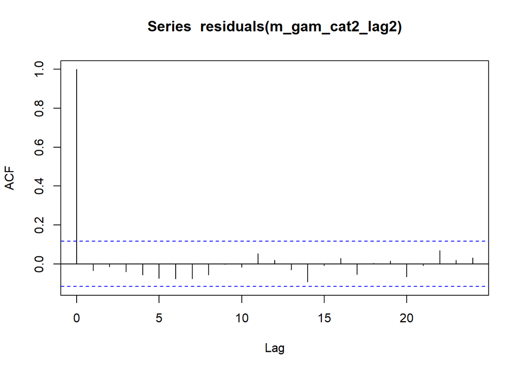

```r
m_gam_cat2_lag2 <- gam(
  Chla_log ~ Year_fct * StationCode + s(Week, bs = "cc", k = 5) + lag1 + lag2,
  data = df_chla_c2_lag,
  method = "REML",
  knots = list(week = c(0, 52))
)

acf(residuals(m_gam_cat2_lag2))
```

```r
Box.test(residuals(m_gam_cat2_lag2), lag = 20, type = 'Ljung-Box')
```

```
##
##  Box-Ljung test
##
## data:  residuals(m_gam_cat2_lag2)
## X-squared = 14.052, df = 20, p-value = 0.8279
```

The model with 1 lag term already seems to address the serial autocorrelation, but the lag2 model is even better. Let’s use AIC to see how they compare.

### Compare Models

```r
AIC(m_gam_cat2, m_gam_cat2_lag1, m_gam_cat2_lag2)
```

```
##                       df      AIC
## m_gam_cat2      23.80557 382.3995
## m_gam_cat2_lag1 24.57483 200.3556
## m_gam_cat2_lag2 25.58907 189.8429
```

Again, it looks like the lag2 model has the best fit according to the AIC values. Let’s take a closer look at that one.

### Lag 2 model summary

```r
summary(m_gam_cat2_lag2)
```

```
##
## Family: gaussian
## Link function: identity
##
## Formula:
## Chla_log ~ Year_fct * StationCode + s(Week, bs = "cc", k = 5) +
##     lag1 + lag2
##
## Parametric coefficients:
##                               Estimate Std. Error t value Pr(>|t|)
## (Intercept)                   3.810369   0.496266   7.678 3.28e-13 ***
## Year_fct2016                 -0.259782   0.130906  -1.984 0.048253 *
## Year_fct2017                 -0.093160   0.120489  -0.773 0.440116
## Year_fct2018                 -0.114755   0.119466  -0.961 0.337660
## Year_fct2019                 -0.015790   0.118796  -0.133 0.894360
## StationCodeSTTD              -0.243671   0.125324  -1.944 0.052936 .
## StationCodeLIB               -0.714169   0.146451  -4.877 1.88e-06 ***
## StationCodeRVB               -0.736391   0.149591  -4.923 1.52e-06 ***
## lag1                          0.753790   0.060094  12.543  < 2e-16 ***
## lag2                         -0.158328   0.060905  -2.600 0.009867 **
## Year_fct2016:StationCodeSTTD  0.371220   0.182013   2.040 0.042409 *
## Year_fct2017:StationCodeSTTD -0.030086   0.186161  -0.162 0.871738
## Year_fct2018:StationCodeSTTD -0.111226   0.173052  -0.643 0.520964
## Year_fct2019:StationCodeSTTD -0.401320   0.173509  -2.313 0.021506 *
## Year_fct2016:StationCodeLIB   0.595813   0.184824   3.224 0.001427 **
## Year_fct2017:StationCodeLIB   0.099092   0.165276   0.600 0.549327
## Year_fct2018:StationCodeLIB  -0.690350   0.189863  -3.636 0.000334 ***
## Year_fct2019:StationCodeLIB  -0.284119   0.171038  -1.661 0.097890 .
## Year_fct2016:StationCodeRVB   0.252084   0.174056   1.448 0.148740
## Year_fct2017:StationCodeRVB  -0.038284   0.164998  -0.232 0.816701
## Year_fct2018:StationCodeRVB   0.001762   0.162307   0.011 0.991349
## Year_fct2019:StationCodeRVB  -0.279779   0.164629  -1.699 0.090432 .
## ---
## Signif. codes:  0 '***' 0.001 '**' 0.01 '*' 0.05 '.' 0.1 ' ' 1
##
## Approximate significance of smooth terms:
##           edf Ref.df     F  p-value
## s(Week) 2.164      3 4.538 0.000802 ***
## ---
## Signif. codes:  0 '***' 0.001 '**' 0.01 '*' 0.05 '.' 0.1 ' ' 1
##
## R-sq.(adj) =  0.907   Deviance explained = 91.5%
## -REML = 108.14  Scale est. = 0.10428   n = 284
```

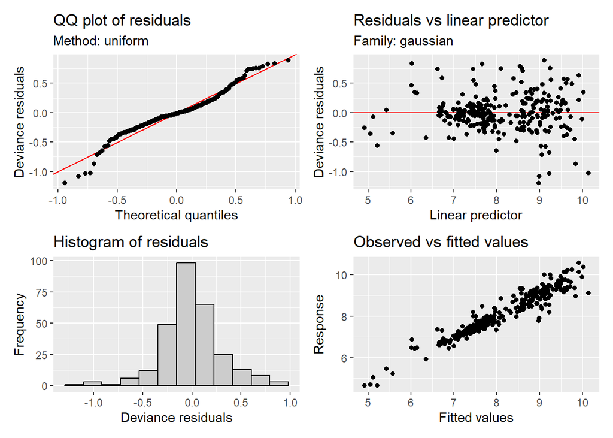

```r
appraise(m_gam_cat2_lag2)
```

```r
shapiro.test(residuals(m_gam_cat2_lag2))
```

```
##
##  Shapiro-Wilk normality test
##
## data:  residuals(m_gam_cat2_lag2)
## W = 0.95429, p-value = 9.186e-08
```

```r
k.check(m_gam_cat2_lag2)
```

```
##         k'      edf   k-index p-value
## s(Week)  3 2.163534 0.9370215   0.155
```

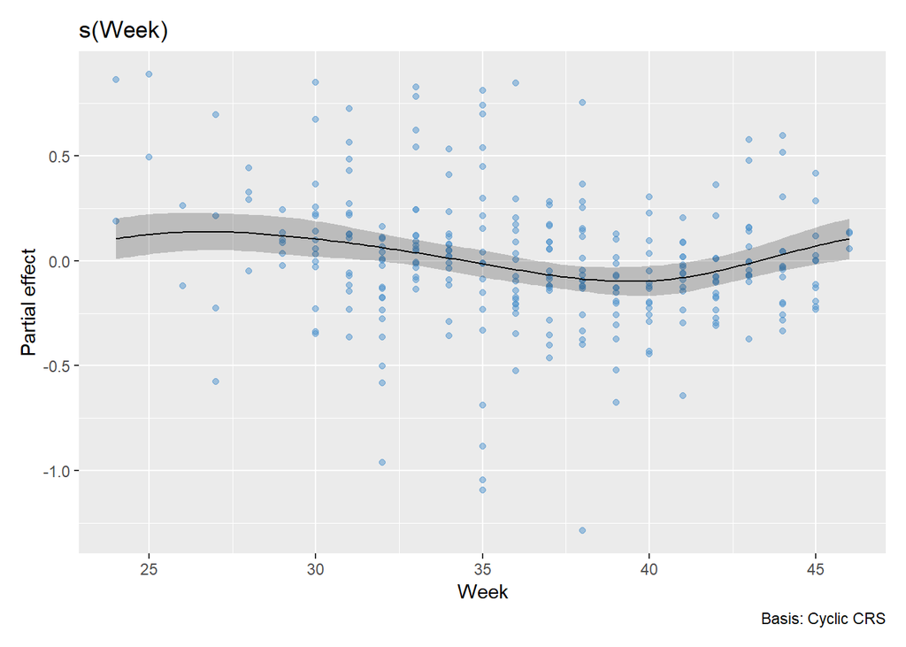

```r
draw(m_gam_cat2_lag2, select = 1, residuals = TRUE, rug = FALSE)
```

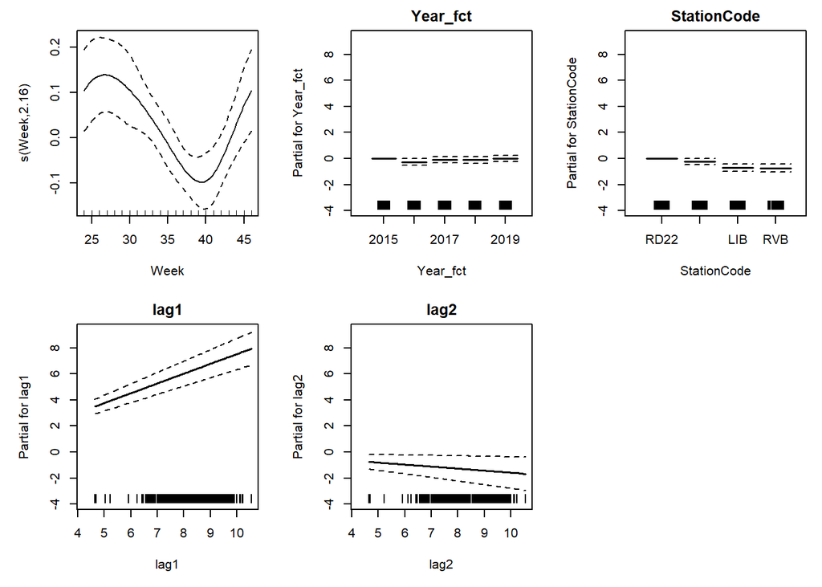

```r
plot(m_gam_cat2_lag2, pages = 1, all.terms = TRUE)
```

```r
anova(m_gam_cat2_lag2)
```

```
##
## Family: gaussian
## Link function: identity
##
## Formula:
## Chla_log ~ Year_fct * StationCode + s(Week, bs = "cc", k = 5) +
##     lag1 + lag2
##
## Parametric Terms:
##                      df       F  p-value
## Year_fct              4   1.260 0.286020
## StationCode           3  10.211 2.22e-06
## lag1                  1 157.339  < 2e-16
## lag2                  1   6.758 0.009867
## Year_fct:StationCode 12   3.168 0.000307
##
## Approximate significance of smooth terms:
##           edf Ref.df     F  p-value
## s(Week) 2.164  3.000 4.538 0.000802
```

The model diagnostics look pretty good but not quite as good as with the initial model. We’ll use `m_gam_cat2_lag2` in the model selection process.

```r
rm(m_gam_cat2, m_gam_cat2_lag1)
```

# Model 4: Linear Model with Flow and 3-way interactions

Let’s try the weekly average model as a linear model with a three-way interaction between Year, Weekly Average Flow, and Station but without the smooth term for week number. Initially, we’ll run the model without accounting for serial autocorrelation.

## Initial Model

```r
m_lm_flow3 <- lm(Chla_log ~ Year_fct * Flow * StationCode, data = df_chla_c2)
```

Lets look at the model summary and diagnostics:

```r
summary(m_lm_flow3)
```

```
##
## Call:
## lm(formula = Chla_log ~ Year_fct * Flow * StationCode, data = df_chla_c2)
##
## Residuals:
##      Min       1Q   Median       3Q      Max
## -0.97374 -0.19702 -0.02017  0.16626  1.33105
##
## Coefficients:
##                                     Estimate Std. Error t value Pr(>|t|)
## (Intercept)                        9.7615689  0.1149026  84.955  < 2e-16 ***
## Year_fct2016                      -0.7803006  0.1662325  -4.694 4.17e-06 ***
## Year_fct2017                      -1.2750955  0.2533518  -5.033 8.59e-07 ***
## Year_fct2018                      -0.3716521  0.1542539  -2.409 0.016617 *
## Year_fct2019                      -0.1064280  0.1515132  -0.702 0.482984
## Flow                              -0.0021678  0.0005067  -4.278 2.58e-05 ***
## StationCodeSTTD                   -1.1482782  0.1453232  -7.902 6.10e-14 ***
## StationCodeLIB                    -2.0659490  0.1403787 -14.717  < 2e-16 ***
## StationCodeRVB                    -2.1117161  0.1403787 -15.043  < 2e-16 ***
## Year_fct2016:Flow                  0.0028066  0.0008103   3.464 0.000615 ***
## Year_fct2017:Flow                  0.0498038  0.0128457   3.877 0.000131 ***
## Year_fct2018:Flow                  0.0004445  0.0007085   0.627 0.530893
## Year_fct2019:Flow                 -0.0000748  0.0006226  -0.120 0.904452
## Year_fct2016:StationCodeSTTD       1.2499596  0.2136261   5.851 1.34e-08 ***
## Year_fct2017:StationCodeSTTD       1.7155377  0.3407645   5.034 8.53e-07 ***
## Year_fct2018:StationCodeSTTD      -0.2869259  0.2037980  -1.408 0.160256
## Year_fct2019:StationCodeSTTD      -0.9572118  0.2007104  -4.769 2.96e-06 ***
## Year_fct2016:StationCodeLIB        1.7614390  0.2054580   8.573 6.59e-16 ***
## Year_fct2017:StationCodeLIB        1.3626781  0.2886090   4.722 3.68e-06 ***
## Year_fct2018:StationCodeLIB       -1.8236205  0.2044106  -8.921  < 2e-16 ***
## Year_fct2019:StationCodeLIB       -0.6043253  0.1995777  -3.028 0.002688 **
## Year_fct2016:StationCodeRVB        0.9752324  0.2069080   4.713 3.82e-06 ***
## Year_fct2017:StationCodeRVB        1.0593695  0.2886090   3.671 0.000289 ***
## Year_fct2018:StationCodeRVB        0.0493574  0.1940940   0.254 0.799451
## Year_fct2019:StationCodeRVB       -0.7029752  0.1938728  -3.626 0.000341 ***
## Flow:StationCodeSTTD               0.0049297  0.0007794   6.325 9.84e-10 ***
## Flow:StationCodeLIB                0.0028763  0.0007599   3.785 0.000187 ***
## Flow:StationCodeRVB                0.0018144  0.0007599   2.388 0.017609 *
## Year_fct2016:Flow:StationCodeSTTD -0.0043111  0.0011917  -3.618 0.000352 ***
## Year_fct2017:Flow:StationCodeSTTD -0.0352894  0.0145777  -2.421 0.016114 *
## Year_fct2018:Flow:StationCodeSTTD -0.0007185  0.0010472  -0.686 0.493211
## Year_fct2019:Flow:StationCodeSTTD -0.0012877  0.0009279  -1.388 0.166310
## Year_fct2016:Flow:StationCodeLIB  -0.0032468  0.0011734  -2.767 0.006027 **
## Year_fct2017:Flow:StationCodeLIB  -0.0483336  0.0131090  -3.687 0.000272 ***
## Year_fct2018:Flow:StationCodeLIB   0.0017105  0.0010495   1.630 0.104231
## Year_fct2019:Flow:StationCodeLIB  -0.0008137  0.0009237  -0.881 0.379107
## Year_fct2016:Flow:StationCodeRVB  -0.0031157  0.0011756  -2.650 0.008493 **
## Year_fct2017:Flow:StationCodeRVB  -0.0472314  0.0131090  -3.603 0.000371 ***
## Year_fct2018:Flow:StationCodeRVB  -0.0007736  0.0010268  -0.753 0.451830
## Year_fct2019:Flow:StationCodeRVB   0.0007609  0.0009095   0.837 0.403500
## ---
## Signif. codes:  0 '***' 0.001 '**' 0.01 '*' 0.05 '.' 0.1 ' ' 1
##
## Residual standard error: 0.3591 on 284 degrees of freedom
## Multiple R-squared:  0.8977, Adjusted R-squared:  0.8837
## F-statistic: 63.92 on 39 and 284 DF,  p-value: < 2.2e-16
```

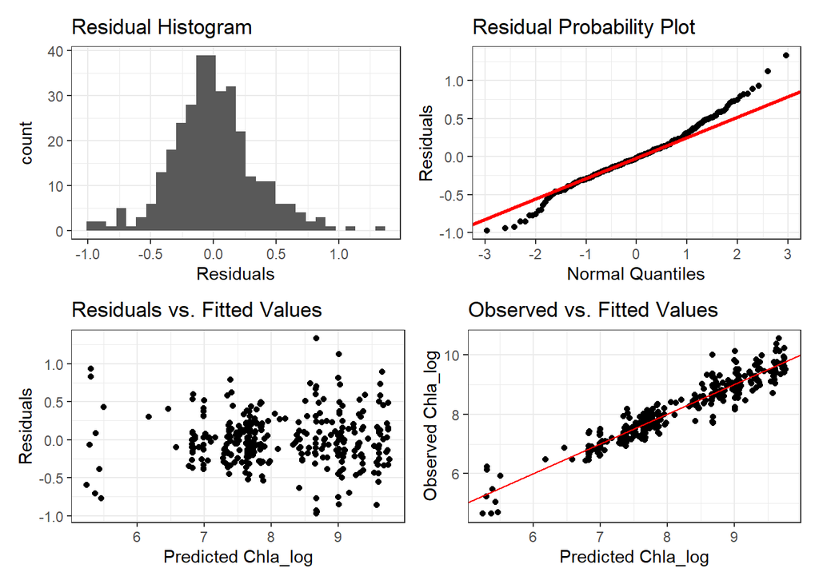

```r
df_chla_c2 %>% plot_lm_diag(Chla_log, m_lm_flow3)
```

```r
shapiro.test(residuals(m_lm_flow3))
```

```
##
##  Shapiro-Wilk normality test
##
## data:  residuals(m_lm_flow3)
## W = 0.98191, p-value = 0.0004191
```

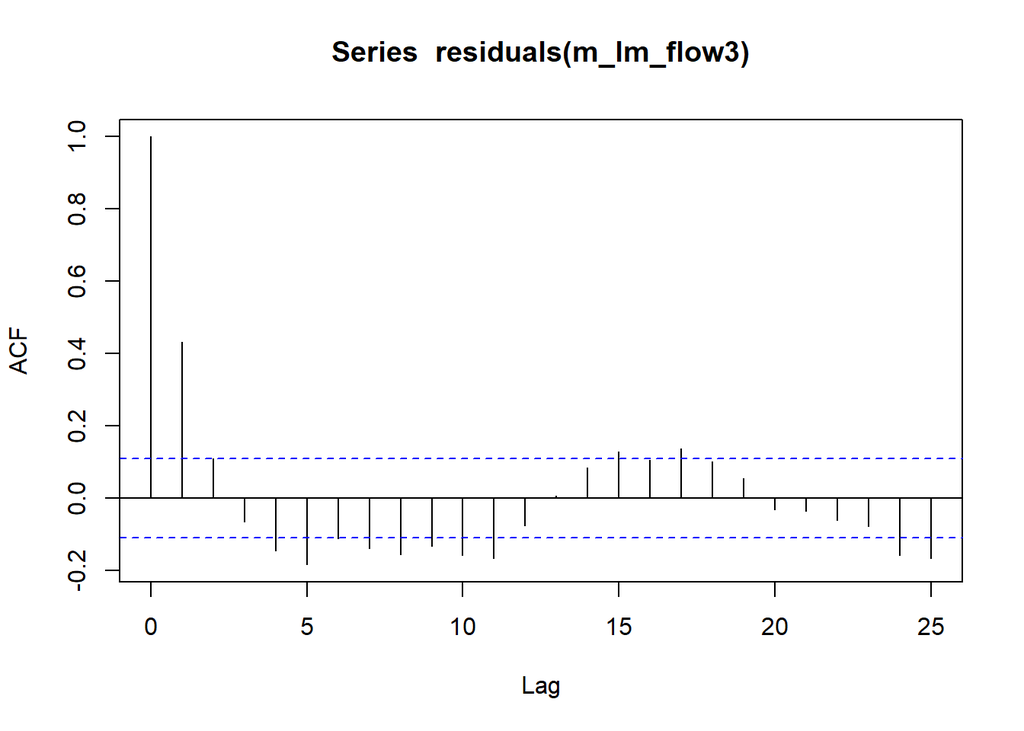

```r
acf(residuals(m_lm_flow3))
```

```r
Box.test(residuals(m_lm_flow3), lag = 20, type = 'Ljung-Box')
```

```
##
##  Box-Ljung test
##
## data:  residuals(m_lm_flow3)
## X-squared = 151.84, df = 20, p-value < 2.2e-16
```

The residuals deviate from a normal distribution according to visual inspection and the Shapiro-Wilk normality test. Also, model definitely has residual autocorrelation as indicated by the ACF plot and the Box-Ljung test.